# IE440 - HW1 - Group 6

Alihan Zer - Özlem Şenel - İrem Öztürk - Onur Can Aydın

06 11 2021

In this homework, we are asked to find a local minimum of this function between values a = -10 and b = 10:

f(x) = x^3 cos(x) sin(x) + 3x^2sin(x)-3x

Also, we are asked to find this value in several ways, which are:

- Bisection Method
- Golden Section Method
- Newton’s Method
- Secant Method

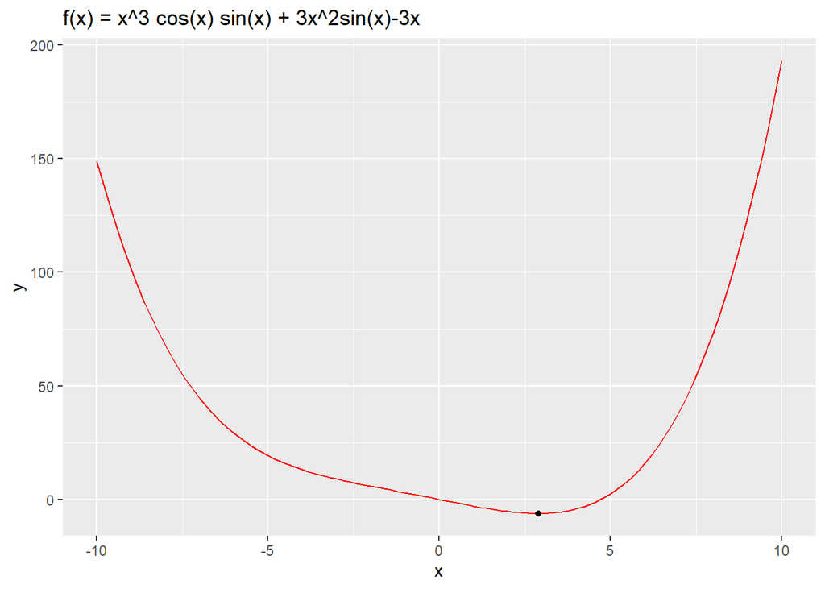

This point shown in the graph is the global minimum point of this function. In all methods, x converges to this point in this graph.

```r
feq1 = function(x3,x2,x1, c){
  return(abs(x3-x2)/abs((x2-x1)^c))
}

feq2 = function(x3,x2,x1){
  return(log(abs(x2 - x1)) - log(abs(x3 - x2)))
}
```

## Bisection Method

#### E = 0.005

```r
bisection = function(f, a, b, eps){
vec_k = c()
vec_a = c()
vec_b = c()
vec_x = c()
vec_fx = c()
vec_eq1 = c()
vec_eq2 = c()
counter = 0

while(b-a>=eps){
  x = (a+b)/2
  counter = counter + 1
  if(f(x+eps)<f(x)){
    a = x
  }
  else{
    b = x
  }
  vec_k[counter] = counter
  vec_x[counter] = x
  vec_a[counter] = a
  vec_b[counter] = b
  vec_fx[counter] = f(x)
}

for(i in (1:counter)){
  vec_eq1[i] = feq1(vec_x[i+1], vec_x[i], vec_x[i-1], c = 1)
  vec_eq2[i] = feq2(vec_x[i+1], vec_x[i], vec_x[i-1])
}
bisection_table = data.table(vec_k,vec_a, vec_b, vec_x, vec_fx, vec_eq1, vec_eq2)
 return(bisection_table)
}

bt = bisection(f, -10, 10, 0.005)
colnames(bt) = c("Iteration", "a", "b", "x", "f(x)", "eq1", "eq2")
bt
```

```
##     Iteration        a         b        x      f(x) eq1       eq2
##  1:         1 0.000000 10.000000 0.000000  0.000000  NA        NA
##  2:         2 0.000000  5.000000 5.000000  2.389692 0.5 0.6931472
##  3:         3 2.500000  5.000000 2.500000 -6.001232 0.5 0.6931472
##  4:         4 2.500000  3.750000 3.750000 -5.049197 0.5 0.6931472
##  5:         5 2.500000  3.125000 3.125000 -6.116719 0.5 0.6931472
##  6:         6 2.812500  3.125000 2.812500 -6.182792 0.5 0.6931472
##  7:         7 2.812500  2.968750 2.968750 -6.183566 0.5 0.6931472
##  8:         8 2.812500  2.890625 2.890625 -6.191265 0.5 0.6931472
##  9:         9 2.851562  2.890625 2.851562 -6.189005 0.5 0.6931472
## 10:        10 2.871094  2.890625 2.871094 -6.190635 0.5 0.6931472
## 11:        11 2.880859  2.890625 2.880859 -6.191075 0.5 0.6931472
## 12:        12 2.885742  2.890625 2.885742 -6.191202  NA        NA
```

This table shows all iterations. The epsilon value was chosen as 0.005.

Additionally, the optimal point and its value is:

```r
c(bt[.N, x], bt[.N, f(x)])
```

```
## [1]  2.885742 -6.191202
```

We can also choose a different epsilon value.

#### E = 0.001

```r
bt2 = bisection(f, -10, 10, 0.001)
colnames(bt2) = c("Iteration", "a", "b", "x", "f(x)", "eq1", "eq2")

bt2
```

```
##     Iteration        a         b        x      f(x) eq1       eq2
##  1:         1 0.000000 10.000000 0.000000  0.000000  NA        NA
##  2:         2 0.000000  5.000000 5.000000  2.389692 0.5 0.6931472
##  3:         3 2.500000  5.000000 2.500000 -6.001232 0.5 0.6931472
##  4:         4 2.500000  3.750000 3.750000 -5.049197 0.5 0.6931472
##  5:         5 2.500000  3.125000 3.125000 -6.116719 0.5 0.6931472
##  6:         6 2.812500  3.125000 2.812500 -6.182792 0.5 0.6931472
##  7:         7 2.812500  2.968750 2.968750 -6.183566 0.5 0.6931472
##  8:         8 2.890625  2.968750 2.890625 -6.191265 0.5 0.6931472
##  9:         9 2.890625  2.929688 2.929688 -6.189482 0.5 0.6931472
## 10:        10 2.890625  2.910156 2.910156 -6.190884 0.5 0.6931472
## 11:        11 2.890625  2.900391 2.900391 -6.191202 0.5 0.6931472
## 12:        12 2.890625  2.895508 2.895508 -6.191265 0.5 0.6931472
## 13:        13 2.890625  2.893066 2.893066 -6.191273 0.5 0.6931472
## 14:        14 2.891846  2.893066 2.891846 -6.191271 0.5 0.6931472
## 15:        15 2.892456  2.893066 2.892456 -6.191272  NA        NA
```

The optimal point and its value is:

```r
c(bt2[.N, x], bt2[.N, f(x)])
```

```
## [1]  2.892456 -6.191272
```

#### E = 0.0005

```r
bt3 = bisection(f, -10 , 10, 0.0005)
colnames(bt3) = c("Iteration", "a", "b", "x", "f(x)", "eq1", "eq2")
bt3
```

```
##     Iteration        a         b        x      f(x) eq1       eq2
##  1:         1 0.000000 10.000000 0.000000  0.000000  NA        NA
##  2:         2 0.000000  5.000000 5.000000  2.389692 0.5 0.6931472
##  3:         3 2.500000  5.000000 2.500000 -6.001232 0.5 0.6931472
##  4:         4 2.500000  3.750000 3.750000 -5.049197 0.5 0.6931472
##  5:         5 2.500000  3.125000 3.125000 -6.116719 0.5 0.6931472
##  6:         6 2.812500  3.125000 2.812500 -6.182792 0.5 0.6931472
##  7:         7 2.812500  2.968750 2.968750 -6.183566 0.5 0.6931472
##  8:         8 2.890625  2.968750 2.890625 -6.191265 0.5 0.6931472
##  9:         9 2.890625  2.929688 2.929688 -6.189482 0.5 0.6931472
## 10:        10 2.890625  2.910156 2.910156 -6.190884 0.5 0.6931472
## 11:        11 2.890625  2.900391 2.900391 -6.191202 0.5 0.6931472
## 12:        12 2.890625  2.895508 2.895508 -6.191265 0.5 0.6931472
## 13:        13 2.890625  2.893066 2.893066 -6.191273 0.5 0.6931472
## 14:        14 2.891846  2.893066 2.891846 -6.191271 0.5 0.6931472
## 15:        15 2.892456  2.893066 2.892456 -6.191272 0.5 0.6931472
## 16:        16 2.892761  2.893066 2.892761 -6.191273  NA        NA
```

The optimal point and its value is:

```r
c(bt3[.N, x], bt3[.N, f(x)])
```

```
## [1]  2.892761 -6.191273
```

## Golden Search

#### E = 0.005

```r
golden_section <-function(a,b,eps,f){

  x = b - 0.618 * (b-a)
  y = a + 0.618 * (b-a)
  fx = f(x)
  fy = f(y)
  counter=0
  vec_k<-c()
  vec_a<-c()
  vec_b<-c()
  vec_x<-c()
  vec_y<-c()
  vec_fx<-c()
  vec_fy <-c()
  vec_eq1 <- c()
  vec_eq2 <- c()

  while(b-a >= eps){

    counter = counter + 1

    if(fx > fy){
      a <- x
      x <- y
      fx <- fy
      y <- a + 0.618 * (b-a)
      fy <- f(y)
    }
    else{
      b <- y
      y <- x
      x <- b - 0.618 * (b-a)
      fy <- fx
      fx <- f(x)
    }

    vec_k[counter]=counter
    vec_a[counter]=a
    vec_b[counter]=b
    vec_x[counter]=x
    vec_y[counter]=y
    vec_fx[counter]=fx
    vec_fy[counter]=fy
  }
  vec_k <- append(vec_k, 0,after=0)
  vec_a <- append(vec_a, -10,after=0)
  vec_b <- append(vec_b, 10,after=0)
  vec_x <- append(vec_x, -2.36,after=0)
  vec_y <- append(vec_y, 2.36 ,after=0)
  vec_fx <- append(vec_fx, f(-2.36),after=0)
  vec_fy <- append(vec_fy, f(2.36),after=0)

  for(i in (1:counter)){
  vec_eq1[i] = feq1(vec_x[i+1], vec_x[i], vec_x[i-1], c = 1)
  vec_eq2[i] = feq2(vec_x[i+1], vec_x[i], vec_x[i-1])
  }

  vec_eq1 <- append(vec_eq1, NA ,after=0)
  vec_eq2 <- append(vec_eq2, NA ,after=0)


  dt_golden <- data.table(vec_k,vec_a, vec_b, vec_x,vec_y, vec_fx, vec_fy, vec_eq1, vec_eq2)
colnames(dt_golden) =  c ("Iteration", "a", "b", "x", "y", "f(x)", "f(y)", "eq1", "eq2")
  return(dt_golden)

}

gt = golden_section(-10, 10, 0.005, f)


gt
```

```
##     Iteration           a         b          x        y      f(x)      f(y)
##  1:         0 -10.0000000 10.000000 -2.3600000 2.360000  6.932760 -5.851166
##  2:         1  -2.3600000 10.000000  2.3600000 5.278480 -5.851166  5.326926
##  3:         2  -2.3600000  5.278480  0.5578994 2.360000 -1.662915 -5.851166
##  4:         3   0.5578994  5.278480  2.3600000 3.475218 -5.851166 -5.689969
##  5:         4   0.5578994  3.475218  1.6723152 2.360000 -4.635673 -5.851166
##  6:         5   1.6723152  3.475218  2.3600000 2.786509 -5.851166 -6.176512
##  7:         6   2.3600000  3.475218  2.7865092 3.049205 -6.176512 -6.157964
##  8:         7   2.3600000  3.049205  2.6232763 2.786509 -6.099578 -6.176512
##  9:         8   2.6232763  3.049205  2.7865092 2.886500 -6.176512 -6.191216
## 10:         9   2.7865092  3.049205  2.8865001 2.948855 -6.191216 -6.187101
## 11:        10   2.7865092  2.948855  2.8485254 2.886500 -6.188663 -6.191216
## 12:        11   2.8485254  2.948855  2.8865001 2.910529 -6.191216 -6.190867
## 13:        12   2.8485254  2.910529  2.8722108 2.886500 -6.190698 -6.191216
## 14:        13   2.8722108  2.910529  2.8865001 2.895892 -6.191216 -6.191262
```

[output cut: 25 more lines]

The optimal point and its value is:

```r
c(gt[.N, x], gt[.N, f(x)])
```

```
## [1]  2.893674 -6.191272
```

#### E = 0.001

```r
gt3 = golden_section(-10, 10, 0.001, f)
gt3
```

```
##     Iteration           a         b          x        y      f(x)      f(y)
##  1:         0 -10.0000000 10.000000 -2.3600000 2.360000  6.932760 -5.851166
##  2:         1  -2.3600000 10.000000  2.3600000 5.278480 -5.851166  5.326926
##  3:         2  -2.3600000  5.278480  0.5578994 2.360000 -1.662915 -5.851166
##  4:         3   0.5578994  5.278480  2.3600000 3.475218 -5.851166 -5.689969
##  5:         4   0.5578994  3.475218  1.6723152 2.360000 -4.635673 -5.851166
##  6:         5   1.6723152  3.475218  2.3600000 2.786509 -5.851166 -6.176512
##  7:         6   2.3600000  3.475218  2.7865092 3.049205 -6.176512 -6.157964
##  8:         7   2.3600000  3.049205  2.6232763 2.786509 -6.099578 -6.176512
##  9:         8   2.6232763  3.049205  2.7865092 2.886500 -6.176512 -6.191216
## 10:         9   2.7865092  3.049205  2.8865001 2.948855 -6.191216 -6.187101
## 11:        10   2.7865092  2.948855  2.8485254 2.886500 -6.188663 -6.191216
## 12:        11   2.8485254  2.948855  2.8865001 2.910529 -6.191216 -6.190867
## 13:        12   2.8485254  2.910529  2.8722108 2.886500 -6.190698 -6.191216
## 14:        13   2.8722108  2.910529  2.8865001 2.895892 -6.191216 -6.191262
```

[output cut: 33 more lines]

The optimal point and its value is:

```r
c(gt3[.N, x], gt3[.N, f(x)])
```

```
## [1]  2.893051 -6.191273
```

#### E = 0.0005

```r
gt2 = golden_section(-10, 10, 0.0005, f)
gt2
```

```
##     Iteration           a         b          x        y      f(x)      f(y)
##  1:         0 -10.0000000 10.000000 -2.3600000 2.360000  6.932760 -5.851166
##  2:         1  -2.3600000 10.000000  2.3600000 5.278480 -5.851166  5.326926
##  3:         2  -2.3600000  5.278480  0.5578994 2.360000 -1.662915 -5.851166
##  4:         3   0.5578994  5.278480  2.3600000 3.475218 -5.851166 -5.689969
##  5:         4   0.5578994  3.475218  1.6723152 2.360000 -4.635673 -5.851166
##  6:         5   1.6723152  3.475218  2.3600000 2.786509 -5.851166 -6.176512
##  7:         6   2.3600000  3.475218  2.7865092 3.049205 -6.176512 -6.157964
##  8:         7   2.3600000  3.049205  2.6232763 2.786509 -6.099578 -6.176512
##  9:         8   2.6232763  3.049205  2.7865092 2.886500 -6.176512 -6.191216
## 10:         9   2.7865092  3.049205  2.8865001 2.948855 -6.191216 -6.187101
## 11:        10   2.7865092  2.948855  2.8485254 2.886500 -6.188663 -6.191216
## 12:        11   2.8485254  2.948855  2.8865001 2.910529 -6.191216 -6.190867
## 13:        12   2.8485254  2.910529  2.8722108 2.886500 -6.190698 -6.191216
## 14:        13   2.8722108  2.910529  2.8865001 2.895892 -6.191216 -6.191262
```

[output cut: 37 more lines]

The optimal point and its value is:

```r
c(gt2[.N, x], gt2[.N, f(x)])
```

[output not shown]

## Netwon’s Method

#### E = 0.005

```r
derivative = function(k, ff){
  x = k
  eval(D(ff, 'x'))
}

second_derivative = function(k, ff){
  x = k
  eval(D(D(ff, 'x'), 'x'))
}

newton = function(x0, eps, f, ff){
  counter = 0
  vec_k = c()
  vec_xk = c()
  vec_fxk = c()
  vec_dfxk = c()
  vec_ddfxk = c()
  vec_eq1 = c()

  while(1){
    counter = counter + 1
    x1 = x0 - (derivative(x0, ff)/second_derivative(x0, ff))
    if(abs(derivative(x1, ff)) < eps){
      vec_k[counter] = counter
      vec_xk[counter] = x1
      vec_fxk[counter] = f(x1)
      vec_dfxk[counter] = derivative(x1, ff)
      vec_ddfxk[counter] = second_derivative(x1, ff)
      break
    }
    vec_k[counter] = counter
    vec_xk[counter] = x1
    vec_fxk[counter] = f(x1)
    vec_dfxk[counter] = derivative(x1, ff)
    vec_ddfxk[counter] = derivative(x1, ff)
    x0 = x1

    }
  for(i in (1:counter)){
    vec_eq1[i] = feq1(vec_xk[i+1], vec_xk[i], vec_xk[i-1], c = 2)
  }
  newton_table = data.table(vec_k, vec_xk, vec_fxk, vec_dfxk, vec_ddfxk,vec_eq1)
  colnames(newton_table) = c("Iteration", "x_k", "f(x_k)", "f'(x_k)", "f''(x_k)", "eq1")

 return(newton_table)
  }

nt = newton(10, 0.005, f, ff)
nt
```

```
##    Iteration      x_k    f(x_k)      f'(x_k)   f''(x_k)       eq1
## 1:         1 6.506760 25.889713 22.611760778 22.6117608        NA
## 2:         2 4.394910 -2.258394  5.920606713  5.9206067 0.2466594
## 3:         3 3.294830 -5.960344  1.192527988  1.1925280 0.2991245
## 4:         4 2.932837 -6.189159  0.106700756  0.1067008 0.3000605
## 5:         5 2.893517 -6.191273  0.001179036  2.6538116        NA
```

The optimal point and its value is:

```r
c(nt[.N, x_k], nt[.N, f(x_k)])
```

```
## [1]  2.893517 -6.191273
```

#### E = 0.001

```r
nt2 = newton(10, 0.001, f, ff)
nt2
```

```
##    Iteration      x_k    f(x_k)      f'(x_k)     f''(x_k)       eq1
## 1:         1 6.506760 25.889713 2.261176e+01 22.611760778        NA
## 2:         2 4.394910 -2.258394 5.920607e+00  5.920606713 0.2466594
## 3:         3 3.294830 -5.960344 1.192528e+00  1.192527988 0.2991245
## 4:         4 2.932837 -6.189159 1.067008e-01  0.106700756 0.3000605
## 5:         5 2.893517 -6.191273 1.179036e-03  0.001179036 0.2873683
## 6:         6 2.893073 -6.191273 1.494706e-07  2.653138791        NA
```

The optimal point and its value is:

```r
c(nt2[.N, x_k], nt2[.N, f(x_k)])
```

```
## [1]  2.893073 -6.191273
```

#### E = 0.0005

```r
nt3 = newton(10, 0.0005, f, ff)
nt3
```

```
##    Iteration      x_k    f(x_k)      f'(x_k)     f''(x_k)       eq1
## 1:         1 6.506760 25.889713 2.261176e+01 22.611760778        NA
## 2:         2 4.394910 -2.258394 5.920607e+00  5.920606713 0.2466594
## 3:         3 3.294830 -5.960344 1.192528e+00  1.192527988 0.2991245
## 4:         4 2.932837 -6.189159 1.067008e-01  0.106700756 0.3000605
## 5:         5 2.893517 -6.191273 1.179036e-03  0.001179036 0.2873683
## 6:         6 2.893073 -6.191273 1.494706e-07  2.653138791        NA
```

The optimal point and its value is:

```r
c(nt3[.N, x_k], nt3[.N, f(x_k)])
```

```
## [1]  2.893073 -6.191273
```

## Secant Method

#### E = 0.005

```r
secant = function(x0, x1, eps, f, ff){

    counter = 0
    vec_k = c()
    vec_xk = c()
    vec_fxk = c()
    vec_fdxk= c()
    vec_eq3 = c()
    while(1){
    counter = counter + 1
    x2 = x1 - ((derivative(x1, ff)) / ((derivative(x1, ff) - derivative(x0, ff)))) * (x1 - x0)

    if(abs(derivative(x2, ff)) < eps){
      vec_k[counter] = counter
      vec_xk[counter] = x2
      vec_fxk[counter] = f(x2)
      vec_fdxk[counter] = derivative(x2, ff)
      break
    }
    vec_k[counter] = counter
    vec_xk[counter] = x2
    vec_fxk[counter] = f(x2)
    vec_fdxk[counter] = derivative(x2, ff)
    x0 = x1
    x1 = x2

    }
  for(i in (1:counter)){
    vec_eq3[i] = (abs(vec_xk[i+1] - vec_xk[i])) / abs(vec_xk[i] - vec_xk[i-1])^1.618
  }
  secant_table = data.table(vec_k, vec_xk, vec_fxk, vec_fdxk, vec_eq3)
  colnames(secant_table) = c("Iteration", "x_k", "f(x_k)", "f'(x_k)",  "eq1")

 return(secant_table)
}




st = secant(10, x1_finder(10, f), 0.005, f, ff)
colnames(st) = c("Iteration", "x_k", "f(x_k)", "f'(x_k)",  "eq1")
st
```

```
##    Iteration      x_k    f(x_k)      f'(x_k)       eq1
## 1:         1 5.137036  3.766606 1.052404e+01        NA
## 2:         2 3.944501 -4.410721 3.705149e+00 0.4873405
## 3:         3 3.296519 -5.958326 1.198093e+00 0.6248568
## 4:         4 2.986855 -6.179396 2.555330e-01 0.5594590
## 5:         5 2.902904 -6.191144 2.615617e-02 0.5272001
## 6:         6 2.893331 -6.191273 6.842393e-04        NA
```

The optimal point and its value is:

```r
c(st[.N, x_k], st[.N, f(x_k)])
```

```
## [1]  2.893331 -6.191273
```

#### E = 0.001

```r
st2 = secant(10,x1_finder(10, f), 0.001, f, ff)
st2
```

```
##    Iteration      x_k    f(x_k)      f'(x_k)       eq1
## 1:         1 5.137036  3.766606 1.052404e+01        NA
## 2:         2 3.944501 -4.410721 3.705149e+00 0.4873405
## 3:         3 3.296519 -5.958326 1.198093e+00 0.6248568
## 4:         4 2.986855 -6.179396 2.555330e-01 0.5594590
## 5:         5 2.902904 -6.191144 2.615617e-02 0.5272001
## 6:         6 2.893331 -6.191273 6.842393e-04        NA
```

The optimal point and its value is:

```r
c(st2[.N, x_k], st2[.N, f(x_k)])
```

```
## [1]  2.893331 -6.191273
```

#### E = 0.0005

```r
st3 = secant(10,x1_finder(10, f), 0.0005, f, ff)
st3
```

```
##    Iteration      x_k    f(x_k)      f'(x_k)       eq1
## 1:         1 5.137036  3.766606 1.052404e+01        NA
## 2:         2 3.944501 -4.410721 3.705149e+00 0.4873405
## 3:         3 3.296519 -5.958326 1.198093e+00 0.6248568
## 4:         4 2.986855 -6.179396 2.555330e-01 0.5594590
## 5:         5 2.902904 -6.191144 2.615617e-02 0.5272001
## 6:         6 2.893331 -6.191273 6.842393e-04 0.4751776
## 7:         7 2.893074 -6.191273 1.915855e-06        NA
```

The optimal point and its value is:

```r
c(st3[.N, x_k], st3[.N, f(x_k)])
```

```
## [1]  2.893074 -6.191273
```